# BSAN2204

Lecture 7

Regression

## Predictive Analytics

Predictive analytics involves using historical data to forecast future outcomes. A core method of predictive analytics is **regression**, which models relationships between multiple variables to estimate an outcome of interest, i.e., **song hotness** in the case of the *Predictive Analytics Report (A2)*.

Methods of predictive analytics can also be used to deal with missing data using multiple imputation. The accuracy of predictive models can be assessed through methods of model validation. These comprise using the parameters estimated during model training to predict known values in test data.

## Regression

Regression is a broad term for a set of methods used to predict an output variable (also called a criterion, dependent, or response variable) from one or more feature variables (also called explanatory, independent, or predictor variables).

Regression is used to identify feature variables that are related to an output variable, to establish the functional form of the relationship between the feature and output variables, and to predict the value of an output variable based on values of the feature variables.

In BSAN2204, we will use the terminology of **input** and **output** variables.

## History of regression

Regression has been an essential tool of statistical analysis for over **200 years**. Astronomy was one of the earliest scientific fields where OLS was applied. In this context, the input variables were the measured quantities of time and position (angles, coordinates) from telescopic observations, and the output variable was the predicted orbital path of a celestial body (e.g., a planet, comet, or asteroid).

Whilst in astronomy, regression was used to fit noisy observational data (planet positions over time) in business analytics, regression is used to fit (explain) various types of noisy data. In both cases, the goal is the same: extract a reliable underlying pattern from imperfect measurements to make accurate **predictions**.

## Where is regression used today?

Regression is most visible in traditional predictive models (linear regression for continuous outcomes, logistic regression for categorical outcomes). The principles of regression are embedded in complex machine learning systems, hence they are important for anyone studying business analytics to be aware of.

Modern generative models are also based on prediction using algorithms related to regression. A large language model (LLM), for example, generates outputs by predicting the next “token” (text, pixels, sound) based on patterns it has learned from training data. These outputs are optimised to be as close as possible to outputs the AI has “seen” before, much like how regression models produce predictions based on the minimisation of the residual errors between the predicted values and actual values (the line of best fit through a series of data points).

## The slopes of straight lines

The mechanics of forecasting and prediction with linear regression depend on interpreting the slopes of straight lines (gradients).

Knowing the slope of a regression line allows the analyst to how the forecast values of an outcome variable (within a known level of precision) will change given changes in the values of input variables.

Some forecasts can be made exactly (i.e., with no error) when the phenomena is *deterministic*. Take for example the effect of a variable like `hourly_wage` on the outcome `take_home_pay`. In this context, the effect of a change in wage can be calculated perfectly and plotting this relationship would comprise a straight line that fits perfectly through a series of data points.

## A deterministic model

```r
hourly_wage <- 10:25
hours_worked <- rep(20, length(hourly_wage))
take_home_pay <- hourly_wage * hours_worked
df <- data.frame(hourly_wage, take_home_pay)

plot(df$hourly_wage, df$take_home_pay,
     xlab = "Hourly Wage",
     ylab = "Take-Home Pay",
     main = "Effect of Hourly Wage on Take-Home Pay (20hr/week)")
grid(col = "gray")

model <- lm(take_home_pay ~ hourly_wage)

abline(model)
legend("bottomright", legend = paste("slope =", summary(model)$coefficients[2]), bty = "n")
```

The slope of the line above is 20, which perfectly describes what happens to `take_home_pay` when `hourly_wage` changes (assuming a fixed number of hours worked). There are 0 errors in the forecast.

## A deterministic model

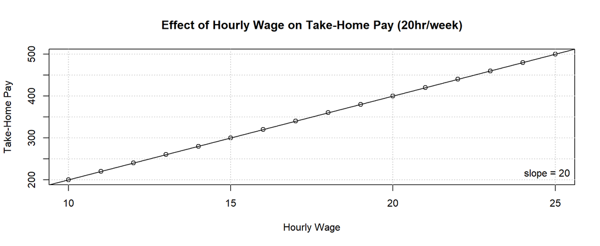

## Non-deterministic models

```r
set.seed(2204)
study_hours <- seq(0, 20, by = 1)
performance <- 50 + 2.5 * study_hours + rnorm(length(study_hours), mean = 0, sd = 5)
df <- data.frame(study_hours, performance)

plot(df$study_hours, df$performance,
     xlab = "Hours Spent Studying",
     ylab = "Class Performance (%)",
     main = "Effect of Study Time on Class Performance")
grid(col = "gray")

model <- lm(performance ~ study_hours, data = df)

abline(model)
legend("bottomright", legend = paste("slope =", summary(model)$coefficients[2] |> round(2)), bty = "n")
```

Non-deterministic models have *error* in their forecasts. The slope of the line in the example above is 2.69, which approximates the effect of `hours_spent_studying` on `class_performance` (i.e., the model is not estimate perfectly).

## Non-deterministic models

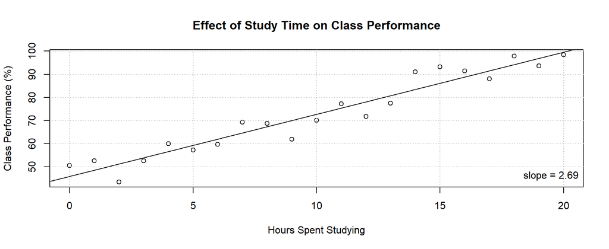

## Errors (residuals)

```r
set.seed(2204)
study_hours <- seq(0, 20, by = 1)
performance <- 50 + 2.5 * study_hours + rnorm(length(study_hours), mean = 0, sd = 5)
df <- data.frame(study_hours, performance)

plot(df$study_hours, df$performance,
     xlab = "Hours Spent Studying",
     ylab = "Class Performance (%)",
     main = "Effect of Study Time on Class Performance")
grid(col = "gray")

model <- lm(performance ~ study_hours, data = df)

abline(model)
legend("bottomright", legend = paste("R-squared =", summary(model)$r.squared |> round(2)), bty = "n")

y_hat <- predict(model)
x <- df$study_hours
y <- df$performance
segments(x0 = x, y0 = y, x1 = x, y1 = y_hat, col = "red", lwd = 1)
```

The distance between the line and the data are the errors (residuals). The $R^2$ value of a model measures how much of the total variation in the data is explained by the model, while the residuals reflect the unexplained variance.

## Errors (residuals)

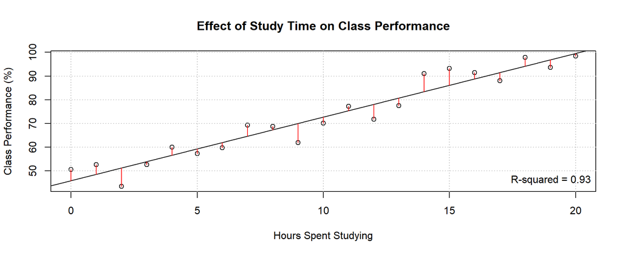

## Precursors to regression

Methods of exploratory analysis (descriptive statistics and data visualisations) are commonly used prior to running regression models to first understand the contents of a dataset. The insights drawn from these analyses will often inform how regression models are specified.

Exploratory analyses may indicate there are bivariate relationships or trends between a variable and some outcome of interest, but they are insufficient on their own to suggest directional influence (causality).

Regression analyses can be used to explore these relationships in a *multivariate model*. This allows the analyst to control for potential confounding factors and interactions among variables.

## Specifying models

Regression model specification comprises choosing what variables to include. We need to specify what the output variable is, what the input variables are, and what the functional forms of the relationships between the input variables and the output variable are (linear or non-linear, main effects or interaction effects).

In a regression equation, the output variable is denoted by $\hat{Y}$. Input variables are denoted by $x_{1...i}$ (i.e., $x_1$ for input variable 1, $x_2$ for input variable 2, etc.)

The functional forms of the relationships are captured by transformations to the input variables, including non-linear or interaction effects (e.g, ${x_1}^2$ or ${x_1}\times{x_2}$). If no transformations are applied, only linear main effects are estimated.

## Using a regression equation

A regression equation can be used to summarise a model specification. They are commonly used in academic papers, although tend not to appear in industry focussed business analytics reports. In addition to the input and output variables, the equation includes the parameters for estimation for each input variable, i.e., $\hat{\beta}_{1...i}$, which will reveal the marginal effect of each input variable.

$$\hat{Y}_i = \hat{\beta}_0 + \hat{\beta}_1 x_{1,i} + \cdots + \hat{\beta}_k x_{k,i}, \quad i = 1, \dots, n$$

In `R`, the syntax of the `lm()` simplifies this equation down to just in the output variable and a list of input variables.

You do not need to include an equation in your *Predictive Analytics Report (A2)*, but you should be able to interpret a regression equation if you ever see one!

## Choosing variables

Model specification is the process of choosing **input** variable(s) and the **output** variable.

For example in model for the determinants of fuel efficiency in cars, miles per gallon (`mpg`) is the output variable, whilsts a list of input variables might be car weight (`wt`) and horsepower (`hp`). As a regression **equation** this is:

$$\widehat{mpg}
=
\hat{\beta}_0 +
\hat{\beta}_1 \cdot wt +
\hat{\beta}_2 \cdot hp$$

## Selecting an output variable

The outcome variable is what is of theoretical interest to the analyst to be able to predict. In business analytics contexts, it will be a variable which understanding the drivers of will lead to strategic advantages.

For example, if we know what inputs account for variability in customer preferences, then we can design products which have the highest probability of being chosen in a market.

## Selecting input variables

The variables chosen as *inputs* should ideally be variables which can be practically used in prediction.

Exploratory analysis might reveal variables that might be bivariate relationships with an outcome variable. A novice regression modeller may naively conclude that all such variables should be included as input variables in a regression model.

A more nuanced approach is to carefully consider the practicality such variables for prediction. If a variable is only known after the outcome occurs then it cannot be used to predict that outcome in real time. Further, if a variable is only reliably available in training data (but not in real world data), then it may be practical to use for prediction.

## Selecting *practical* input variables

When building a regression model, selecting input variables is not just about statistical relevance, it is also about practical availability. A model is only as useful as the data it can access when deployed.

Variables used during model training must be available at prediction time. If a variable is only known after the outcome occurs then it cannot be used to predict that outcome in real time.

## Multicolinearity

Multicollinearity occurs when two or more input variables in a regression model are highly correlated with each other. This makes it difficult to separate their individual effects on the outcome and diminishes the significance of other variables in the model, and misleading interpretations from inflated model fit measures.

When two predictors in a regression model are highly correlated, it may be because they are essentially measuring the same underlying construct (derived from the same input variable). For example, artist and song hotness might be the “same thing”.

## Using path diagrams

Any regression equation can be summarised in a diagram with the output variable on the right hand side in an ellipse (to denote it as a predicted variable) and input variables on the left in boxes (to denote them as observed variables).

$$\widehat{mpg}
=
\hat{\beta}_0 +
\hat{\beta}_1 \cdot wt +
\hat{\beta}_2 \cdot hp$$

[interactive chart not shown]

## Communicating model specifications

In business analytics reports intended for industry focussed clients, you are unlikely to see formal/mathematical representations of models with equations nor path diagrams. Instead, consultants tend to use more “bespoke” ways to communicate (i.e., they will develop their own intuitive ways to describe their analysis in ways which make sense to them/their audiences).

For your *Predictive Analytics Report (A2)*, you need to show your `R` code for specifying your model(s) *at a minimum*.

How you describe your model specification is essentially up to you. You may decide to use a formal/academic representation using equations, path diagrams or develop your own method. What is most important is that you communicate what the specification, and a coherent rationale for that specification.

## Model estimation

The type of regression model we use in BSAN2204 is an *ordinary least squares* (OLS) model. The OLS approach estimates the relationship between the output variable and one or more input variables by minimising the sum of squared residuals.

This method provides unbiased and efficient parameter estimates under the classical linear regression assumptions, making it a cornerstone of statistical modelling.

## Estimates and model fit

In most situations the data we are working with is distributed across many values, meaning the relationship between two or more variables is not exact. The amount of variability in the data means that we can only can only represent relationships in the data *approximately* using a straight line.

The extent to which this *approximation* is accurate (the average distance from a line fit through a cloud of data and each data point within that cloud) is referred to as “model fit”.

The summary statistic $R^2$ is a measure of what percentage of the variance in a model is explained.

## Line of best fit

The best fitting (straight) line through a series of data points with a lot variability between them is a line where the distances between the line and the data is minimised (i.e., errors are minimised).

The line represents our predictions of `y` for given values of `x` whilst its slope represents the strength of association.

This type of regression is referred to as “ordinary least squares” (OLS) regression, which fits a line through the data by minimising the sum of squared residuals. The overall model fit is quantified by $R^2$, representing the proportion of variance in the outcome explained by the model.

## Multiple Regression

So far we have covered simple regression with only one input variable. Regression really is more commonly used to address *multivariate* statistical questions. When a regression model has multiple input variables we refer to it as “multiple regression”.

It has the following form:

$$\hat{Y}_i = \hat{\beta}_0 + \hat{\beta}_1 x_{1,i} + \cdots + \hat{\beta}_k x_{k,i}, \quad i = 1, \dots, n$$
where `n` is the number of observations, `i` is the index of each row number for each observation and `k` is the number of input variables.

## Components of the Regression Equation

Each term in the regression equation plays a distinct role in predicting outcomes from input variables.

$\hat{Y}_i$ is the predicted value of the output variable for observation i,

$\hat{\beta}_0$ is the intercept (the predicted value of Y when the levels of the feature variables are equal to zero),

$\hat{\beta}_1$ is the regression coefficient for the 1st predictor (the slope of the regression line representing the change in $\hat{Y}$ for a unit change in $x_1$), and

$x_{1,i}$ is the level of feature variable for the *i*th observation.

## Multiple Regression in `R`

In `R`, we write out this equation in a simplified form using the `lm()` function.

The basic syntax of `lm()` is as follows:

```r
lm(output_variable ~
input_variable_1
+ input_variable_2
+ ...
+ input_variable_n)
```

`~` separates the output variable from the list of independent variables.

`+` separates each of the input variables

The `lm()` function essentially only includes the $\hat{Y}_i$ (the output variable) and $x_{1} \dots x_{k}$ (the list of input variables) components from the regression equation. The intercept term is included by default.

## `R` syntax of regression models

| Symbol | Description |
| --- | --- |
| `~` | Separates output variables on the left from input variables on the right. For example, `y ~ x + z + w` predicts `y` from `x`, `z`, and `w`. |
| `+` | Separates input variables. |
| `.` | Denotes all other variables. For example, `y ~ .` expands to `y ~ x + z + w`. |
| `–1` | Removes the intercept. For example, `y ~ x –1` fits a regression of `y` on `x` with no intercept. |
| `I()` | Interprets elements arithmetically. For example, `y ~ x + z + I(z^2) + w` adds a new variable (`z` squared) to the equation. |
| `:` | Specifies an interaction effect between input variables. For example, `y ~ x + z + x:z + w` adds an interaction term for `x` and `z`. |

## Running `lm()`

When we run `lm()` we typically save the output to an object in our `R` environment.

```r
model_name <- lm(output_variable ~
                  input_variable_1
                  + input_variable_2
                  + ...
                  + input_variable_n)
```

The above example creates a `list` object called `model_name`, which we will interact with in various ways. The most obvious of these is to extract the model estimates for reporting in tables or text. Other uses include using the model for prediction, performing missing data analysis and model validation steps.

## `R` functions used on `lm()` objects

Below is a non-exhaustive list of functions which are commonly applied to a `lm()` object. The most basic of these is `summary()` which have seen previously. When a `lm()` object is supplied to `summary()` it will print all the elements with the list object to the console window.

| Function | Action |
| --- | --- |
| `summary()` | Displays results for the fitted model. |
| `coefficients()` | Lists the parameters for the fitted model (the regression coefficients). |
| `plot()` | Generates diagnostic plots for evaluating the fit of the estimated model. |
| `predict()` | Uses a fitted model to predict Y values for a new dataset. |

## Regression model specification in `R`

Here are the first 6 rows of the `mtcars` data to remind us of its contents:

|  | mpg | cyl | disp | hp | drat | wt | qsec | vs | am | gear | carb |
| --- | --- | --- | --- | --- | --- | --- | --- | --- | --- | --- | --- |
| Mazda RX4 | 21.0 | 6 | 160 | 110 | 3.90 | 2.620 | 16.46 | 0 | 1 | 4 | 4 |
| Mazda RX4 Wag | 21.0 | 6 | 160 | 110 | 3.90 | 2.875 | 17.02 | 0 | 1 | 4 | 4 |
| Datsun 710 | 22.8 | 4 | 108 | 93 | 3.85 | 2.320 | 18.61 | 1 | 1 | 4 | 1 |
| Hornet 4 Drive | 21.4 | 6 | 258 | 110 | 3.08 | 3.215 | 19.44 | 1 | 0 | 3 | 1 |
| Hornet Sportabout | 18.7 | 8 | 360 | 175 | 3.15 | 3.440 | 17.02 | 0 | 0 | 3 | 2 |
| Valiant | 18.1 | 6 | 225 | 105 | 2.76 | 3.460 | 20.22 | 1 | 0 | 3 | 1 |

What is the combined effect of car `wt` (weight) and `hp` (horsepower) on `mpg` (miles per gallon)?

The model specification for this using `lm()` is:

```r
model1 <- lm(mpg ~ wt + hp)
```

## Output from `summary()`

```r
summary(model1)
```

```
Call:
lm(formula = mpg ~ wt + hp)

Residuals:
   Min     1Q Median     3Q    Max
-3.941 -1.600 -0.182  1.050  5.854

Coefficients:
            Estimate Std. Error t value Pr(>|t|)
(Intercept) 37.22727    1.59879  23.285  < 2e-16 ***
wt          -3.87783    0.63273  -6.129 1.12e-06 ***
hp          -0.03177    0.00903  -3.519  0.00145 **
---
Signif. codes:  0 '***' 0.001 '**' 0.01 '*' 0.05 '.' 0.1 ' ' 1

Residual standard error: 2.593 on 29 degrees of freedom
Multiple R-squared:  0.8268,    Adjusted R-squared:  0.8148
F-statistic: 69.21 on 2 and 29 DF,  p-value: 9.109e-12
```

How well does this model fit? What variable(s) are significant predictors of `mpg`?

## Interpreting regression models

The `lm()` provides many statistica, but the the **three** we will focus on in BSAN2204:

- Model fit: The *adjusted* $R^2$
- Input variable `estimates`, and;
- Input variable `p-values` Pr(>|t|)

## Reporting regression results in R Markdown

The `modelsummary()` function formats regression tables into presentable tables suitable for inclusion in documents.

```r
library(modelsummary)
modelsummary(
  model1,
  stars = TRUE)
```

|  | &nbsp;(1) |
| --- | --- |
| (Intercept) | 37.227*** |
|  | (1.599) |
| wt | −3.878*** |
|  | (0.633) |
| hp | −0.032** |
|  | (0.009) |
| Num.Obs. | 32 |
| R2 | 0.827 |
| R2 Adj. | 0.815 |
| AIC | 156.7 |
| BIC | 162.5 |
| Log.Lik. | −74.326 |
| F | 69.211 |
| RMSE | 2.47 |

+ p < 0.1, * p < 0.05, ** p < 0.01, *** p < 0.001

## Selecting only necessary outputs

The `gof_map =` option should be used to select which *goodness of fit* (gof) measures to include. We only want to keep the number of observations (`"nobs"`) $adj.R^2$ in addition to the `estimates` and their `p-values` denoted using `stars = TRUE` in the main table.

```r
library(modelsummary)
modelsummary(
  model1,
  stars = TRUE,
  gof_map = c("nobs","adj.r.squared"))
```

|  | model1 |
| --- | --- |
| (Intercept) | 37.227*** |
|  | (1.599) |
| wt | −3.878*** |
|  | (0.633) |
| hp | −0.032** |
|  | (0.009) |
| Num.Obs. | 32 |
| R2 Adj. | 0.815 |

+ p < 0.1, * p < 0.05, ** p < 0.01, *** p < 0.001

## Interpreting adjusted $R^2$

$R^2$ is a measure of model fit. It is interpreted as a percentage value to describe the amount of variance in the output variable that the model explains. For example, the adjusted $R^2$ value of 0.8148 in (extracted from `summary(model1)$adj.r.squared`) means the model (overall) explains 81.48% of the variance in the output variable.

There is no minimum of maximum, or threshold, value however our goal should always be to try to increase the amount of variance in the output variable we can explain whilst also maintain model parsimony and interpretability.

This is done through careful selection of which input variables to include, which transformations (if any) are applied to those variables, as well as *dealing with missing data*.

## Why the “adjusted” $R^2$?

The standard $R^2$ will always increase (or stay the same) when additional predictors are included, even if those predictors contribute little or no meaningful explanatory power. The *adjusted* $R^2$ is penalised by accounting for input variables which do not significantly increase the $R^2$.

We prefer the *adjusted* $R^2$ as it only increases when new predictors add a *statistically significant* amount of explanatory power, making it a more reliable metric for comparing models with different numbers of inputs.

The most desirable model is one that achieves the highest possible adjusted $R^2$ using the fewest input variables (i.e., is the most *parsimonious*).

## Input variable `estimates`

The individual estimates ($\beta$’s in the regression equation) tell us the individual level impact for each input variable ($x$’s in the equation). There is no minimum of maximum, or threshold for these estimates.

These values are in the units of the output variable. In the `mtcars` model estimated earlier example, the `estimate` value for `wt` (weight) is -3.88, which means a 1 unit change in `wt` leads to a -3.88 change in `mpg`.

## Input variable `p-values`

The Pr(>|t|) column from the `summary()` output lists the `p-values` for each of the individual input variable estimates.

The `p-value` associated with an estimate is interpreted the same way as the `p-value` for overall significance (i.e., values less than 0.05 indicate statistical significance). Not all estimates will necessarily be significant even if the model is overall significant!

## Overall significance

The `F-statistic` tests the significance of the whole regression model by comparing the estimated model to a null model with only an intercept. Recall that $\hat{\beta}_0$ (the intercept) is the predicted value of $Y$ when the levels of the input variables are set equal to zero.

In a “statistically significant” model the addition of the input variables adds explanatory power. When the `p-value` of the `F-statistic` is small (`p < 0.05`) it gives us confidence that the input variables are not just random noise.

It is useful for the analyst to inspect the `F-statistic` during model development, but we do not need to include it in our final results table. The focus in our document should just be on interpreting (1) the overall model fit $R^2$, (2) the individual coefficient `estimates` and (3) the individual estimates `p-values`.

## Scientific notation in `R`

Very small numbers, like a highly significant `p-value`, will most commonly be printed in *scientific notation* by default `R` output. The scientific notation for the value 0.05 is 5.0e-02. The quick short cut to read this number is to move the decimal point to the left the number of indicated by the power.

For example, a very *very* small number:

```r
small_number <- 0.0000000000045
small_number
```

```
[1] 4.5e-12
```

```
The value stored in `small_number` is `r small_number |> formatC(format = "f")`.
```

The value stored in `small_number` is 0.0000

## `round()` vs `formatC()`

A quick aside to discuss how `R` formats scientific notation… In the notes on *descriptive statistics* `round()` and `formatC()` were both used, and here again we using formatC()`. Which should you use?

In `R`, `round()` is a mathematical rounding function that changes the numeric value itself, while `formatC()` is a formatting function that controls how numbers are displayed (padding, decimal places, alignment) without altering the underlying value.

`formatC()` is generally preferred as it gives us control over how values are displayed when rendered inside R Markdown files.

## Improving predictions

One obvious way to increase the variance explained by a regression model is to add more input variables. Recall we said that $R^2$ will always increase when we add more variables. A regression modeller is like a detective trying to solve a mystery, and each clue gathered is like an input variable in a regression model. Every new clue, even if vague or irrelevant, technically adds more information. The file gets bigger and bigger, but not necessarily more useful. Consider the two models below:

```r
model1 <- lm(mpg ~ wt + hp)
model2 <- lm(mpg ~ wt + hp + cyl + disp + drat + qsec + am + vs)
```

| Metric | `model1` | `model2` | `model2 - model1` |
| --- | --- | --- | --- |
| $R^2$ | 0.8267855 | 0.8677917 | 0.0410062 |
| $adj.R^2$ | 0.8148396 | 0.8218062 | 0.0069666 |

Was adding all those additional variables worth it?

## Non-Linearities

Another way to improve the fit of a regression model is to explore non-linearities in the relationships between certain input variables and the output variable.

Non-linear terms are introduced into regression by transforming variables using arithmetic terms. See in the table presented earlier, the `I()` function is used to interpret elements in the `lm()` syntax arithmetically

For example, `lm(mpg ~ wt + I(wt^2) + hp)` adds a new variable (`wt` squared) to the prediction equation.

## Polynomial regression

Non-linear transformation of variables can lead to a better fitting linear model. The model is still *linear in parameters*, but the relationship between the input variable and output variable is non-linear.

```r
model1 <- lm(mpg ~ wt + hp)
model3 <- lm(mpg ~ wt + I(wt^2) + hp)
```

The new term `I(wt^2)` adds a new variable to the prediction equation and the `I()` function treats the contents within the parentheses as an arithmetic expression.

The difference in the adjusted $R^2$ between the `model1` and `model3` is:  
$R^2_{model1}$ = 0.8148396 vs $R^2_{model3}$ = 0.8581294.

This is a difference of 0.0432898… quite a lot!

## 2nd vs 3rd degree polynomials

A 2nd-degree polynomial creates a parabolic curve with one bend (a U shaped curve). When the coefficient of the quadratic term is positive, `y` initially decreases, reaches a minimum point (the inflection point), and then starts to increase again. When it is negative the effect the other way around.

A 3rd-degree polynomial creates a curve with two bends and hence is a more complex representation of the relationship in the regression model. This allows for relationships to be positive up to a point, then turn negative, then potentially turn positive again.

3rd degree polynomial:

```r
model4 <- lm(mpg ~ wt + I(wt^2) + I(wt^3))
```

## Visualising polynomial effects

```r
plot(
  mtcars$wt, mtcars$mpg,
  xlab = "Weight (1000 lbs)",
  ylab = "Miles per gallon (MPG)",
  main = "MPG vs Weight with Fitted Lines"
)

abline(model1, col = "blue")
ord <- order(mtcars$wt)
lines(mtcars$wt[ord], fitted(model3)[ord], col = "red")
lines(mtcars$wt[ord], fitted(model4)[ord], col = "darkgreen", lty = 3)
```

## Visualising polynomial effects

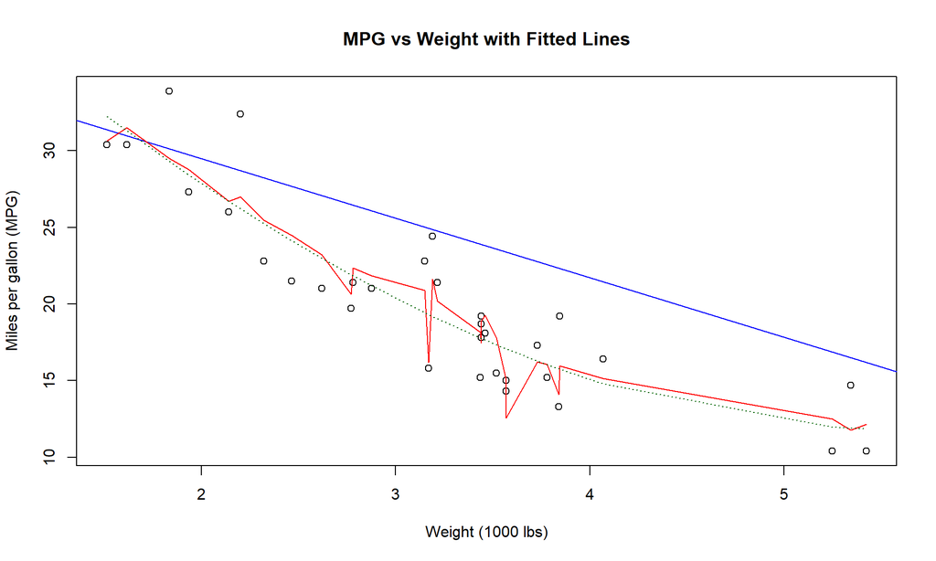

## Interpreting non-linear effects

Including both the original non-transformed variable and its polynomial transformation allows the model to capture both linear and non-linear relationships within the outcome variable.

The relative magnitude and significance of each can be compared to determine which representation explains more variance.

Knowing when/if to include such transformations should be based on having a good grounded theory to support (and explain) such effects if they are significant in the model.

## Interactions

Some of the most interesting analyses are those involving interactions among predictor variables. Interactions are estimated as product terms for the products of input variables with other input variables.

Interactions between variables can also be included in the regression equation using `:` between two (or more) input variables. In the `mtcars` data both weight and horsepower (separately) affect miles per gallon, but maybe the interaction between these two variables will explain more variance.

```r
model5 <- lm(mpg ~ wt + hp:wt)
```

## Visualising interactions

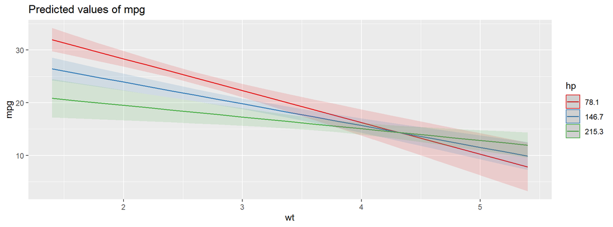

```r
model3 <- lm(mpg ~ wt + hp + hp:wt)
sjPlot::plot_model(model3, type = "int", mdrt.values = "all")
```

The `plot_model()` function from `sjPlot` plots lines for the mean value of the interacted variable one standard deviation above/below the mean effect. See here how the effect of `wt` on `mpg` differs at different levels of `hp`.

## Interpreting interaction terms

Interaction terms can be challenging to interpret. Analysts typically interpret interaction effects with reference the moderating effect of one input variable on the effect of another input variable (on the output variable of interest).

## Grouping different regression tables together

We have seen several different regression models estimated, and discussed how to interpret them but have not shown the outputs.

The outputs for each model are stored in `lm()` model objects which we have named `model1`, `model2`, etc. `modelsummary()` will combined different models together into one neat table when supplied a list of model objects.

```r
modelsummary(list(model1, model2, model3, model4, model5),
  stars = TRUE,
  fmt = 5,
  gof_map = c("Num\\.Obs", "adj.r.squared"))
```

If your output includes escaped white text as **&nbsp** in the model names your output,

set `escape = FALSE` inside your `modelsummary` code.

## `modelsummary()` grouped regression table

|  | (1) | (2) | (3) | (4) | (5) |
| --- | --- | --- | --- | --- | --- |
| (Intercept) | 37.22727*** | 15.57313 | 49.80842*** | 48.40370** | 34.29735*** |
|  | (1.59879) | (16.38173) | (3.60516) | (15.58379) | (2.24202) |
| wt | −3.87783*** | −3.94374** | −8.21662*** | −11.82598 | −3.37105** |
|  | (0.63273) | (1.28744) | (1.26971) | (15.46346) | (1.05013) |
| hp | −0.03177** | −0.02144 | −0.12010*** |  |  |
|  | (0.00903) | (0.01623) | (0.02470) |  |  |
| cyl |  | −0.27859 |  |  |  |
|  |  | (0.93475) |  |  |  |
| disp |  | 0.01471 |  |  |  |
|  |  | (0.01203) |  |  |  |
| drat |  | 0.81506 |  |  |  |
|  |  | (1.51009) |  |  |  |
| qsec |  | 0.80976 |  |  |  |
|  |  | (0.65871) |  |  |  |
| am |  | 2.79375 |  |  |  |
|  |  | (1.86824) |  |  |  |
| vs |  | 0.36836 |  |  |  |
|  |  | (2.01158) |  |  |  |
| wt × hp |  |  | 0.02785*** |  | −0.00653* |
|  |  |  | (0.00742) |  | (0.00300) |
| I(wt^2) |  |  |  | 0.68938 |  |
|  |  |  |  | (4.74034) |  |
| I(wt^3) |  |  |  | 0.04594 |  |
|  |  |  |  | (0.45070) |  |
| R2 Adj. | 0.815 | 0.822 | 0.872 | 0.800 | 0.773 |

+ p < 0.1, * p < 0.05, ** p < 0.01, *** p < 0.001

## Modelling constraints

Some variables may be theoretically useful but difficult or costly to collect in practice. For example, determining the level of a variable might itself require a lengthy, costly or complicated modelling exercise.

Even if a variable is technically available without the above issues, it must be consistently and reliably accessible when the model is being used for prediction. For example, certain variables might only be available for certain observations.

## Ethical considerations

Some variables may be restricted due to privacy laws or ethical concerns. Building a model around such data could lead to compliance issues or breaches of service agreements (particularly with respect to use of certain APIs to scrape data online).

Predictions themselves can raise ethical concerns if they involve sensitive data. Inaccurate or biased forecasts risk causing harm if they lead to misguided strategic decision making. Therefore, an essential duty of a business analyst is to interpret their models both objectively and accurately whilst taking measures to check the robustness of their predictions.

## Model training

Model training is the process of finding the regression model which best describes a set of data. When a dataset is specifically split into a training data and test data, it implies that later in the analysis pipeline will be a check how well the model fitted to the training data performs by using its parameters to predict in the test data.

After a plausible model is found, it is then used for making predictions outside of the training data. In the first instance, analysts typically make predictions in a hold out sample before making predictions using entirely new unseen data. This process is called *model validation*.

## Model testing

In BSAN2204, we take the approach of reserving a hold out sample which we label as “test data”. This holdout sample is not used during training. This step helps confirm whether the model has learned a useful pattern rather than just memorising the training data. Keeping the training data and test data separate is crucial to avoid issues realted to *data leakage*.

We will cover these steps in detail in the model validation sessions.

Thank you!

[figure not shown]